# Louisville Dockless Vehicles: Advanced Visualisation

Luca Baggi

# Load Packages

```r
library(tidyverse)

# alluvial/senkey plots:
library(networkD3)
library(ggalluvial)

# chord plots:
library(circlize)
```

# Load Data

From before, we did:

| TripID | Duration | Distance | StartLatitude | StartLongitude | StartTime | StartNH | EndLatitude | EndLongitude | EndTime | EndNH | ShortTrip | Covid |
| --- | --- | --- | --- | --- | --- | --- | --- | --- | --- | --- | --- | --- |
| 3 | 6 | 531 | 38.259 | -85.733 | 2019-08-21 17:30:00 | Downtown | 38.265 | -85.739 | 2019-08-21 17:30:00 | Northeast Core | 0 | 0 |
| 4 | 6 | 1030 | 38.217 | -85.757 | 2019-07-03 11:00:00 | University | 38.221 | -85.763 | 2019-07-03 11:15:00 | West Core | 0 | 0 |
| 5 | 7 | 964 | 38.215 | -85.759 | 2019-11-22 10:45:00 | University | 38.222 | -85.764 | 2019-11-22 11:00:00 | West Core | 0 | 0 |
| 6 | 7 | 1101 | 38.221 | -85.762 | 2019-05-04 21:15:00 | University | 38.223 | -85.764 | 2019-05-04 21:30:00 | University | 0 | 0 |
| 9 | 10 | 1300 | 38.251 | -85.758 | 2019-06-09 13:30:00 | Downtown | 38.257 | -85.760 | 2019-06-09 13:45:00 | Downtown | 0 | 0 |
| 10 | 4 | 499 | 38.257 | -85.759 | 2018-10-23 17:45:00 | Downtown | 38.254 | -85.758 | 2018-10-23 17:45:00 | Downtown | 0 | 0 |

# Data Wrangling

Before plotting, we need to work with the two way frequency table:

```r
trips %>%
  select(StartNH) %>%
  table() %>%
  sort() %>%
  as_tibble()
```

| . | n |
| --- | --- |
| Floyd's Fork | 0 |
| Jefferson Forest | 7 |
| McNeely Lake | 7 |
| North Floyd | 8 |
| South-Central Dixie | 12 |
| East Metro | 22 |
| Central Taylorsville | 32 |
| Riverport | 38 |
| Northeast Metro | 46 |
| Central Preston | 100 |

[output cut: 12 more lines]

```r
trips %>%
  select(EndNH) %>%
  table() %>%
  sort() %>%
  as_tibble()
```

| . | n |
| --- | --- |
| Floyd's Fork | 0 |
| McNeely Lake | 7 |
| Jefferson Forest | 8 |
| North Floyd | 9 |
| South-Central Dixie | 12 |
| East Metro | 25 |
| Central Taylorsville | 37 |
| Riverport | 42 |
| Northeast Metro | 45 |
| Central Preston | 104 |

[output cut: 12 more lines]

## Twoway Frequency Table

| StartNH | EndNH | n |
| --- | --- | --- |
| Downtown | Downtown | 164912 |
| University | University | 87037 |
| Southeast Core | Southeast Core | 29872 |
| West Core | University | 12257 |
| University | West Core | 9848 |
| Northeast Core | Northeast Core | 8144 |
| Downtown | Northeast Core | 6763 |
| West Core | West Core | 6200 |
| Downtown | University | 5999 |
| University | Downtown | 5618 |

[output cut: 127 more lines]

# Senkey Diagram

## Create the nodes

This already has the desired long format of origin-destination, so we can directly work with the Senkey diagram. To reduce dimensionality, we might want to filter the values.

| StartNH | EndNH | n |
| --- | --- | --- |
| Downtown | Downtown | 164912 |
| University | University | 87037 |
| Southeast Core | Southeast Core | 29872 |
| West Core | University | 12257 |
| University | West Core | 9848 |
| Northeast Core | Northeast Core | 8144 |
| Downtown | Northeast Core | 6763 |
| West Core | West Core | 6200 |
| Downtown | University | 5999 |
| University | Downtown | 5618 |

[output cut: 15 more lines]

What does the last line accomplish? Let’s see in the following code chunks. Let’s create a `nodes` dataframe:

```r
nodes <-
  data.frame(
    node = c(twoway$StartNH, twoway$EndNH)
  ) %>%
  unique()

nodes
```

|  | node |
| --- | --- |
| 1 | Downtown |
| 2 | University |
| 3 | Southeast Core |
| 4 | West Core |
| 6 | Northeast Core |
| 17 | Northwest Core |
| 18 | Southwest Core |
| 20 | East Core |
| 22 | CLARK |
| 26 | Downtown |

[output cut: 8 more lines]

This has created a `nodes` dataframe, which we will use as a base to create the diagram. Adding the trailing whitespace at the end of `twoway$EndNH` made the `nodes` dataframe twice as long, creating objectively different classes of start and end. This is useful because otherwise the diagram would have flows going back to the same neighbourhood (and we want it to look nicer).

## Using `networkD3`

Finally, we can apply `match` to `twoway` and draw the plot:

```r
twoway %>%
  mutate(
    # create two numeric columns for the nodes (think of them as dummies)
    origin = match(twoway$StartNH, nodes$node) - 1,
    destination = match(twoway$StartNH, nodes$node) - 1,
  ) %>%
  as.data.frame() %>%
  sankeyNetwork(
    # Links = twoway is unneded, thanks to the pipe
    Nodes = nodes,
    Source = 'origin',
    Target = 'destination',
    Value = 'n',
    # this belongs to the nodes dataframe
    NodeID = 'node',
    nodeWidth=40, fontSize=13, nodePadding=20
  )
```

[interactive chart not shown]

Aaaand of course, it does not work.

## Using `ggalluvial`

Perhaps it is better to use a different tool. Enter `ggalluvial` and hope for the best.

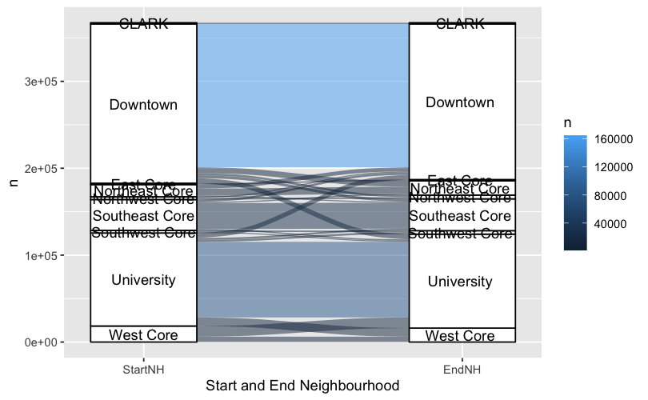

# Drawing a Chord Plot

The matrix we are going to use is still the two-way frequency table (or, in proper terms, adjacency matrix).

## Define some helper functions:

It is already in the `long` format, so we can start plotting straight away. Let’s just rewrite the levels of both columns to make them easier to fit. Since we will be using this more than once, we can define this as a function:

| StartNH | EndNH | n |
| --- | --- | --- |
| 1 | 1 | 242 |
| 1 | 9 | 15 |
| 1 | 18 | 3 |
| 1 | 19 | 3 |
| 1 | 20 | 23 |
| 2 | 2 | 125 |
| 2 | 3 | 2 |
| 2 | 4 | 5 |
| 2 | 6 | 2 |
| 2 | 7 | 1 |

[output cut: 127 more lines]

Then we create the chord diagram:

```r
# not compatible in tidy grammar, sigh

circos.clear() # reset params

circos.par( # set a bunch of stuff
  start.degree = 90,
  gap.degree = 4,
  track.margin = c(-0.1, 0.1),
  points.overflow.warning = FALSE
)

# set plot parameters:
par(mar = # margins
      rep(0,4)) # 0 repeated 4 times
```

Then create the base plot. But we may define a function for this, so that it’s easier to use it later:

```r
# base plot

chord_plot <- function(my_data) {

  chordDiagram(
    x = my_data,
    transparency = 0.25,
    directional = 1,
    direction.type = c("arrows", "diffHeight"),
    diffHeight  = -0.04,
    annotationTrack = "grid",
    annotationTrackHeight = c(0.05, 0.1),
    link.arr.type = "big.arrow",
    link.sort = TRUE,
    link.largest.ontop = TRUE)

  # text and axis
  circos.trackPlotRegion(
    track.index = 1,
    bg.border = NA,
    panel.fun = function(x, y) {

      xlim = get.cell.meta.data("xlim")
      sector.index = get.cell.meta.data("sector.index")

      # Add names to the sector
      circos.text(
        x = mean(xlim),
        y = 3.2,
        labels = sector.index,
        facing = "bending",
        cex = 0.8
        )
    }
  )
}
```

## Plot the Chord Diagrams

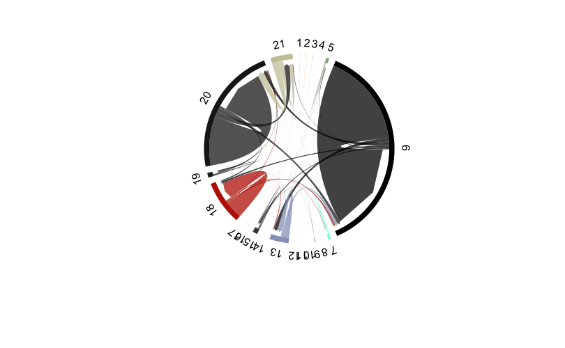

```r
twoway_freq %>%
  prep_cord_data() %>%
  chord_plot()
```

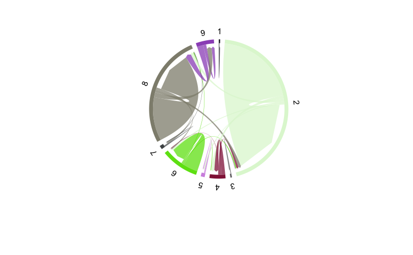

```r
twoway %>%
  prep_cord_data() %>%
  chord_plot()
```